# Exploratory Data Analysis - White Wine Data

# Introduction

In this report, I explored a dataset containing the chemical properties of 4898 white wines and their quality ratings on a scale of 0 to 10. The aim of this exploratory data analysis is to determine chemical properties that influence the quality of white wines.

### Structure of data

```
## 'data.frame':    4898 obs. of  13 variables:
##  $ X                   : int  1 2 3 4 5 6 7 8 9 10 ...
##  $ fixed.acidity       : num  7 6.3 8.1 7.2 7.2 8.1 6.2 7 6.3 8.1 ...
##  $ volatile.acidity    : num  0.27 0.3 0.28 0.23 0.23 0.28 0.32 0.27 0.3 0.22 ...
##  $ citric.acid         : num  0.36 0.34 0.4 0.32 0.32 0.4 0.16 0.36 0.34 0.43 ...
##  $ residual.sugar      : num  20.7 1.6 6.9 8.5 8.5 6.9 7 20.7 1.6 1.5 ...
##  $ chlorides           : num  0.045 0.049 0.05 0.058 0.058 0.05 0.045 0.045 0.049 0.044 ...
##  $ free.sulfur.dioxide : num  45 14 30 47 47 30 30 45 14 28 ...
##  $ total.sulfur.dioxide: num  170 132 97 186 186 97 136 170 132 129 ...
##  $ density             : num  1.001 0.994 0.995 0.996 0.996 ...
##  $ pH                  : num  3 3.3 3.26 3.19 3.19 3.26 3.18 3 3.3 3.22 ...
##  $ sulphates           : num  0.45 0.49 0.44 0.4 0.4 0.44 0.47 0.45 0.49 0.45 ...
##  $ alcohol             : num  8.8 9.5 10.1 9.9 9.9 10.1 9.6 8.8 9.5 11 ...
##  $ quality             : int  6 6 6 6 6 6 6 6 6 6 ...
```

This dataset contains 4898 observations with 13 variables. X refers to the wine’s ID.

As ID is not needed for this analysis, I removed the column from the dataset.

```
## 'data.frame':    4898 obs. of  12 variables:
##  $ fixed.acidity       : num  7 6.3 8.1 7.2 7.2 8.1 6.2 7 6.3 8.1 ...
##  $ volatile.acidity    : num  0.27 0.3 0.28 0.23 0.23 0.28 0.32 0.27 0.3 0.22 ...
##  $ citric.acid         : num  0.36 0.34 0.4 0.32 0.32 0.4 0.16 0.36 0.34 0.43 ...
##  $ residual.sugar      : num  20.7 1.6 6.9 8.5 8.5 6.9 7 20.7 1.6 1.5 ...
##  $ chlorides           : num  0.045 0.049 0.05 0.058 0.058 0.05 0.045 0.045 0.049 0.044 ...
##  $ free.sulfur.dioxide : num  45 14 30 47 47 30 30 45 14 28 ...
##  $ total.sulfur.dioxide: num  170 132 97 186 186 97 136 170 132 129 ...
##  $ density             : num  1.001 0.994 0.995 0.996 0.996 ...
##  $ pH                  : num  3 3.3 3.26 3.19 3.19 3.26 3.18 3 3.3 3.22 ...
##  $ sulphates           : num  0.45 0.49 0.44 0.4 0.4 0.44 0.47 0.45 0.49 0.45 ...
##  $ alcohol             : num  8.8 9.5 10.1 9.9 9.9 10.1 9.6 8.8 9.5 11 ...
##  $ quality             : int  6 6 6 6 6 6 6 6 6 6 ...
```

# Univariate Plots Section

### Quality

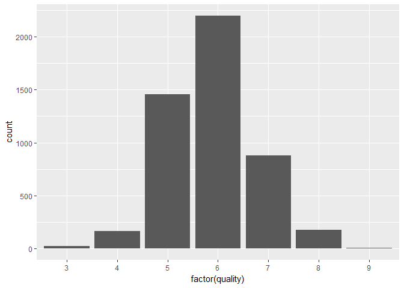

Most wines have a quality rating between 5 to 7 and the most common rating is 6.

### Fixed Acidity

Summary of fixed acidity data:

```
##    Min. 1st Qu.  Median    Mean 3rd Qu.    Max.
##   3.800   6.300   6.800   6.855   7.300  14.200
```

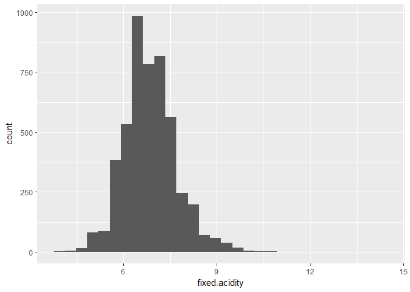

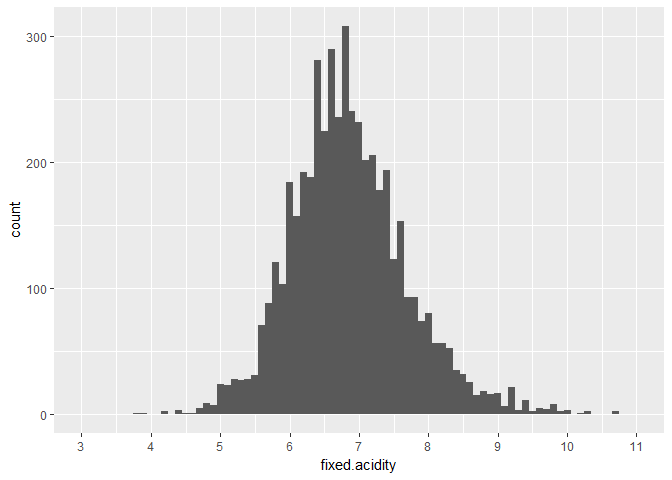

Fixed acitity data is normally ditributed. Most wines have a fixed acidity level between 6 to 7.5 g/dm<sup>3</sup>. There are also some high outliers.

I discovered from online resources that acids affect the mouth feel of wines, so I am curious whether fixed acidity, which measures the concentration of tartaric acid in wines, is linked to wine quality.

## Volatile Acidity

Summary of volatile acidity data:

```
##    Min. 1st Qu.  Median    Mean 3rd Qu.    Max.
##  0.0800  0.2100  0.2600  0.2782  0.3200  1.1000
```

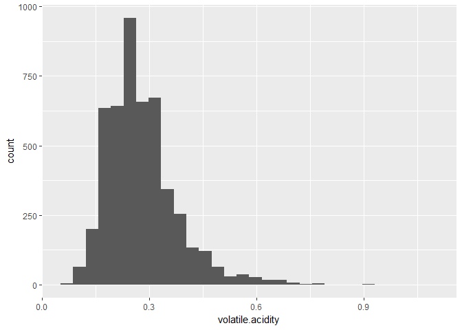

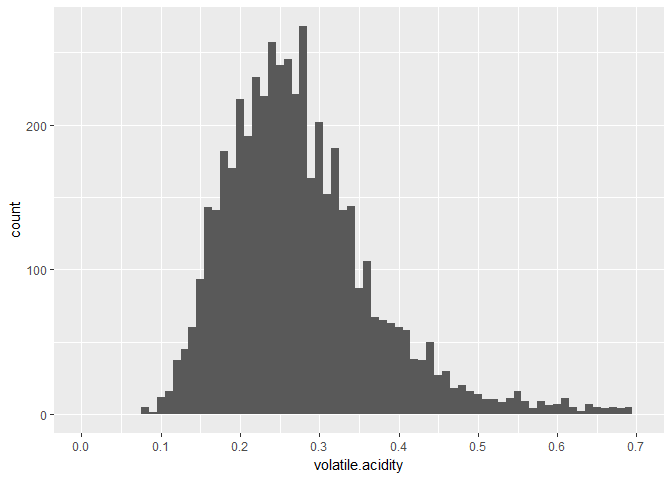

Volatile acidity data, which is the measure of acetic acid concentration, is slightly right-skewed. Most wines have a volatile acidity between 0.15 to 0.35 g/dm<sup>3</sup> and there are some high outliers. According to the documentation in `wineQualityInfo.txt`, high volatile acidity can give wines an unpleasant, vinegar taste, so I wonder if volatile acidity is negatively correlated to quality.

### Citric Acid

Summary of citric acid data:

```
##    Min. 1st Qu.  Median    Mean 3rd Qu.    Max.
##  0.0000  0.2700  0.3200  0.3342  0.3900  1.6600
```

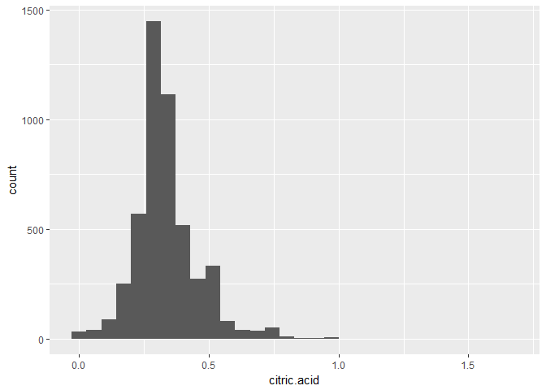

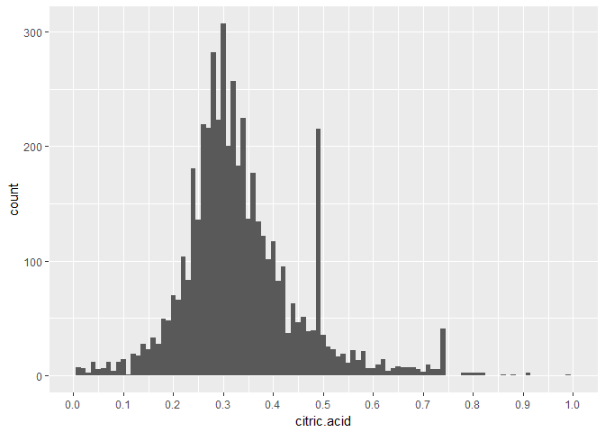

Citric acid levels are quite normally distributed and most wines have citric acid level between 0.20 to 0.40 g/dm<sup>3</sup>. However, there are also many wines with 0.49 g/dm<sup>3</sup> citric acid. In addition, there are some high outliers.

According to the documentation in `wineQualityInfo.txt`, citric acid can add freshness and flavor to wines, so I wonder if citric acid levels affect the quality ratings.

### Residual Sugar

Summary of residual sugar data:

```
##    Min. 1st Qu.  Median    Mean 3rd Qu.    Max.
##   0.600   1.700   5.200   6.391   9.900  65.800
```

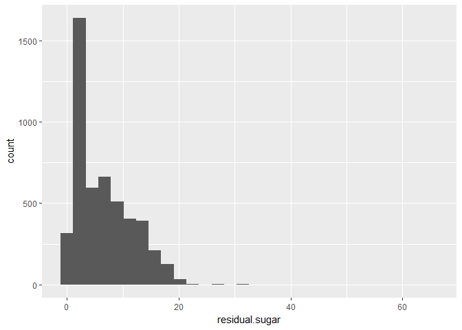

Most wines have residual sugar levels of 20 g/dm<sup>3</sup> and below.

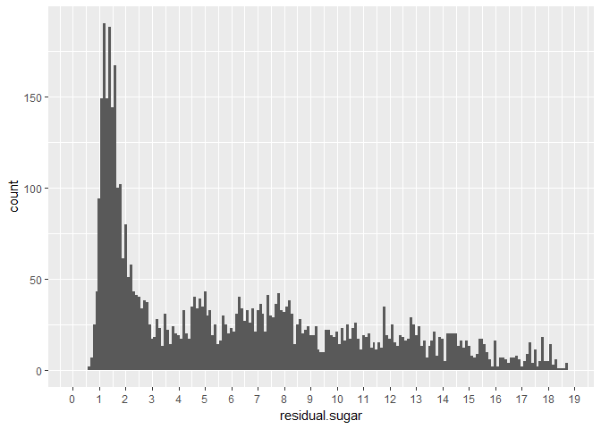

The residual sugar data is right-skewed and has a very long right tail. So, I transformed the scale into log scale.

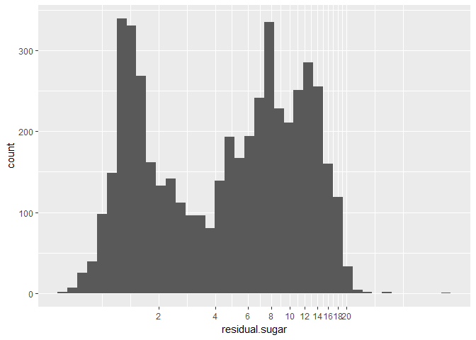

The transformed residual sugar distribution appears to be bimodal and peaks around 1.5 g/dm<sup>3</sup> and 8 g/dm<sup>3</sup>.

Residual sugar level probably affects the sweetness of wines, so I am curious whether it is correlated to quality rating.

### Chlorides

Summary of cholrides data:

```
##    Min. 1st Qu.  Median    Mean 3rd Qu.    Max.
## 0.00900 0.03600 0.04300 0.04577 0.05000 0.34600
```

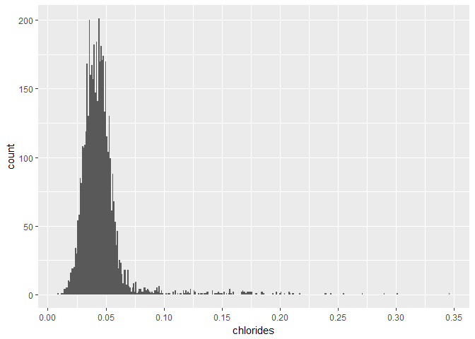

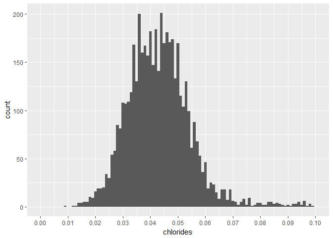

### Free Sulfur Dioxide

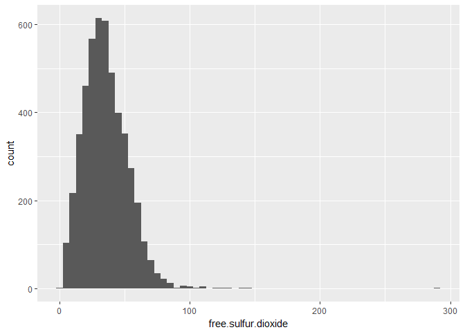

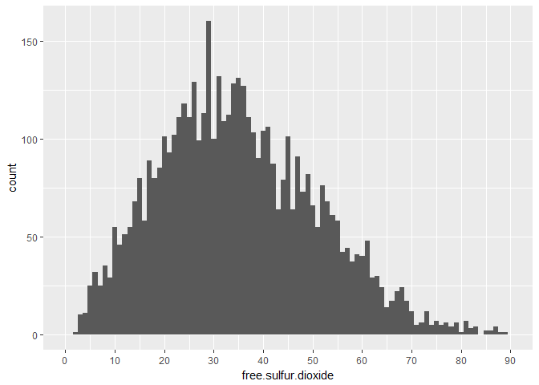

The free sulfur dioxide data is slightly right-skewed. Most wines have free sulfur dioxide levels between 20 to 40 mg/dm<sup>3</sup>. There are also a few high outliers.

### Free Sulfur Dioxide Bucket

According to the documentation `wineQualityInfo.txt`, if free sulfur dioxide in wine is higher than 50 ppm, it gives an obvious smell and taste in the wine. So, I wonder if wines with free sulfur dioxide levels higher than 50 mg/dm<sup>3</sup> have a different rating from those below (assuming 1 mg/dm<sup>3</sup> is approximately 1ppm). To investigate this, I created a column called free.sulfur.dioxide.bucket where wines with free sulfur dioxide levels higher than 50 mg/dm<sup>3</sup> will be assigned the value “>50” and those lower than or equal to 50 mg/dm<sup>3</sup> will be assigned the value “<=50”.

```r
df$free.sulfur.dioxide.bucket <- ifelse(df$free.sulfur.dioxide > 50,
                                        ">50", "<=50")

str(df$free.sulfur.dioxide.bucket)
```

```
##  chr [1:4898] "<=50" "<=50" "<=50" "<=50" "<=50" "<=50" "<=50" "<=50" ...
```

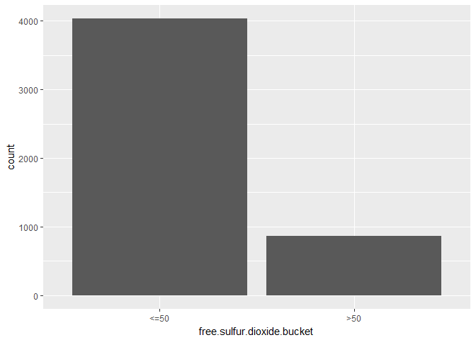

There are much more wines with free sulfur dioxide levels less than or equal to 50 mg/dm<sup>3</sup> compared to those with free sulfur dioxide levels more than 50 mg/dm<sup>3</sup>.

### Total Sulfur Dioxide

Summary of total sulfur dioxide data:

```
##    Min. 1st Qu.  Median    Mean 3rd Qu.    Max.
##     9.0   108.0   134.0   138.4   167.0   440.0
```

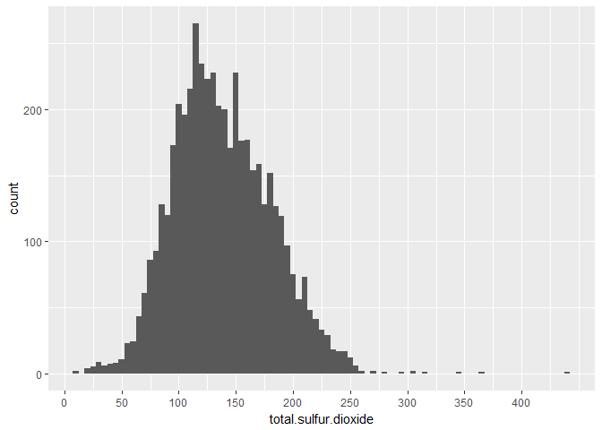

The total sulfur dioxide data is slightly right-skewed. Most wines have total sulfur dioxide levels between 75 to 175 mg/dm<sup>3</sup>.

### Density

Summary of density data:

```
##    Min. 1st Qu.  Median    Mean 3rd Qu.    Max.
##  0.9871  0.9917  0.9937  0.9940  0.9961  1.0390
```

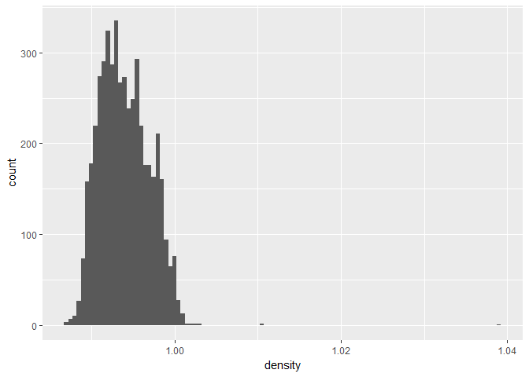

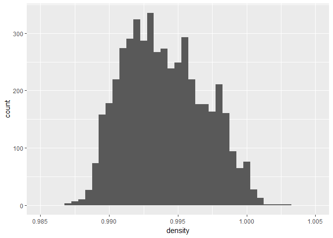

Desnsity data is slightly right-skewered. Most wines have densities between 0.9900 to 0.9975 g/cm<sup>3</sup>. There are also some high outliers.

### pH

Summary of pH data:

```
##    Min. 1st Qu.  Median    Mean 3rd Qu.    Max.
##   2.720   3.090   3.180   3.188   3.280   3.820
```

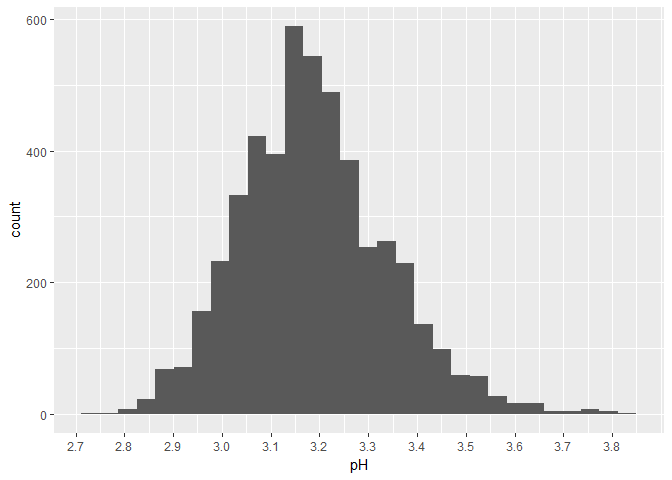

pH data is normally distributed. Most wines have a pH level between 3.00 to 3.35.

## Sulphates

Summary of sulphates data:

```
##    Min. 1st Qu.  Median    Mean 3rd Qu.    Max.
##  0.2200  0.4100  0.4700  0.4898  0.5500  1.0800
```

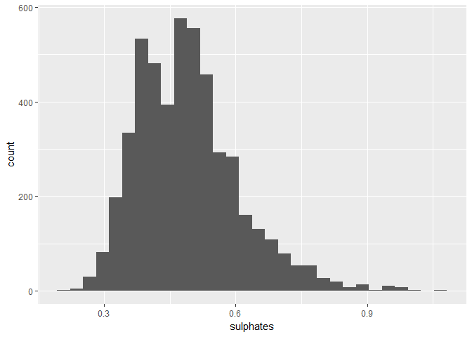

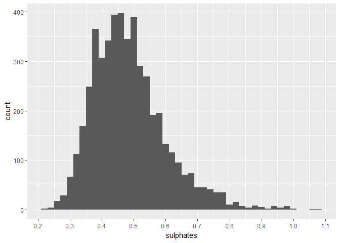

The sulphates data is slightly right-skewed. Most wines have sulphates levels between 0.35 to 0.55 g/dm<sup>3</sup>.

## Alcohol

Summary of alcohol data:

```
##    Min. 1st Qu.  Median    Mean 3rd Qu.    Max.
##    8.00    9.50   10.40   10.51   11.40   14.20
```

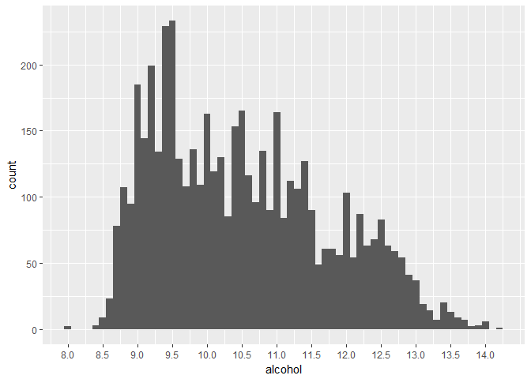

Alcohol data is right-skewed. Most wines have alcohol levels between 9 to 11.5%.

I found from some online resources that alcohols affect the taste of wines, so I am curious whether alcohol levels influence the quality ratings.

As sugar is converted to alcohol during wine fermentation process, having high alcohol content could mean that a greater amount of sugar has been converted to alcohol. So, I wonder if there is an inverse relationship between the alcohol level and residual sugar.

# Univariate Analysis

### What is the structure of your dataset?

- There are 4898 wines in this dataset with 12 variables, which include 11 chemical properties and a quality rating.
- All the variables are either normally distributed or right-skewed.
- The most common quality rating is 6.

### What is/are the main feature(s) of interest in your dataset?

After some online research, I found that sugars and alcohols affect the taste of wines.

The main features of interest are quality rating, residual sugar, and alcohol. It will be interesting to find out how the ratings are affected by residual sugar and alcohol levels.

Other than that, I am also curious about whether alcohol level is residual sugar level are correlated.

### What other features in the dataset do you think will help support your investigation into your feature(s) of interest?

According to online resources, acids probably influence the mouth feel of wines, so the three acidity properties (fixed acidity, volatile acidity, and citric acid) could be somewhat related to quality ratings.

In addition, I suspect that pH could also affect the taste of wines. For example, Wines with lower pH would probably taste more sour. So, I think it will be good to investigate the relationship between pH and quality.

According to the documentation, if free sulfur dioxide in wine is higher than 50 ppm, the it give an obvious smell and taste. So, I wonder if wines with free sulfur dioxide levels higher than 50 mg/dm<sup>3</sup> have a different rating from those below 50 mg/dm<sup>3</sup> (assuming 1 mg/dm<sup>3</sup> is approximately 1ppm).

### Did you create any new variables from existing variables in the dataset?

I created a variable called free.sulfur.dioxide.bucket. In this column, wines with free sulfur dioxide levels higher than 50 mg/dm<sup>3</sup> are assigned the value “>50” and those lower than or equal to 50 mg/dm<sup>3</sup> are assigned the value “<=50”.

### Of the features you investigated, were there any unusual distributions? Did you perform any operations on the data to tidy, adjust, or change the form of the data? If so, why did you do this?

The residual sugar data has a very long tail, so I log-transformed the data. After doing so, the data appears bimodal.

# Bivariate Plots Section

### Correlation matrix

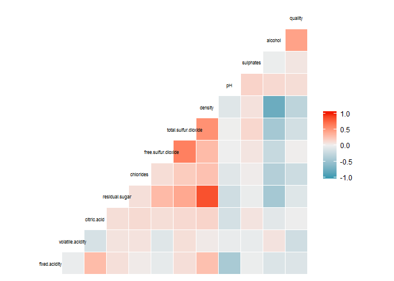

Looking at the correlation matrix generated from a subset of data, only alcohol level is moderately correlated to quality. Residual sugar, fixed acidity, volatile acidity, citric acid, and pH have weak correlations with quality.

Other than that, there is also a moderate negative correlation betweeen residual sugar and alcohol level.

To get a better understanding of the relationships, I will take a closer look at individual bivariate plots.

### Quality and Alcohol

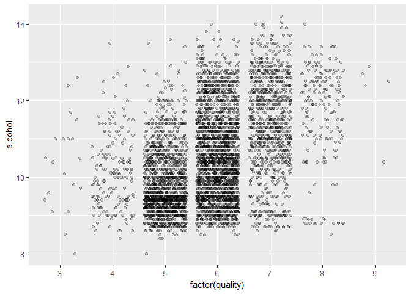

Pearson correlation coefficient:

```
## [1] 0.4355747
```

There is a moderate positive correlation between alcohol level and quality. Wines with higher alcohol levels tend to have higher quality ratings.

Next, I take a look at the median alcohol level for wines at each quality rating.

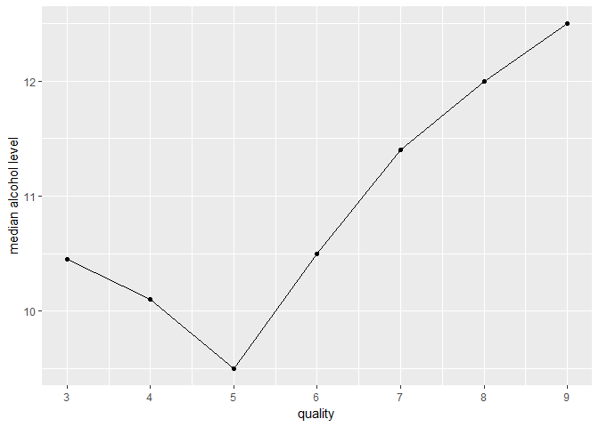

It seems that wines with quality ratings greater than 6 tend to have higher alcohol contents, while those with ratings 6 and below varied in alcohol contents.

### Quality and Residual Sugar

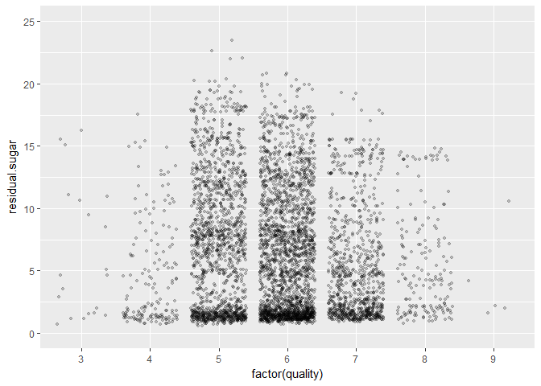

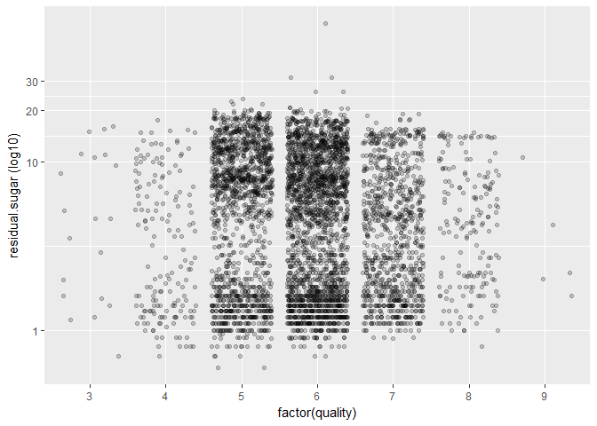

It seems that residual sugar is not really correlated to quality. The quality ratings are varied regardless of residual sugar level.

### Quality and Fixed Acidity

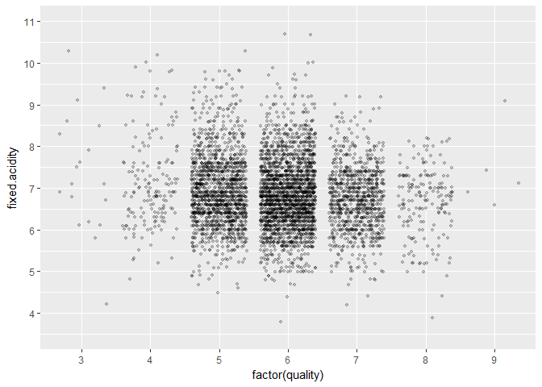

### Quality and Volatile Acidity

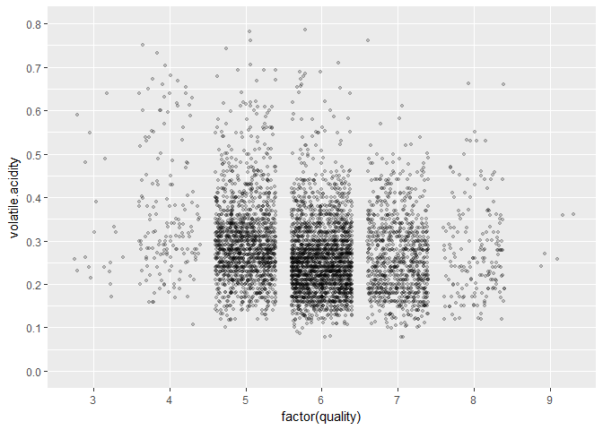

### Quality and Citric Acid Level

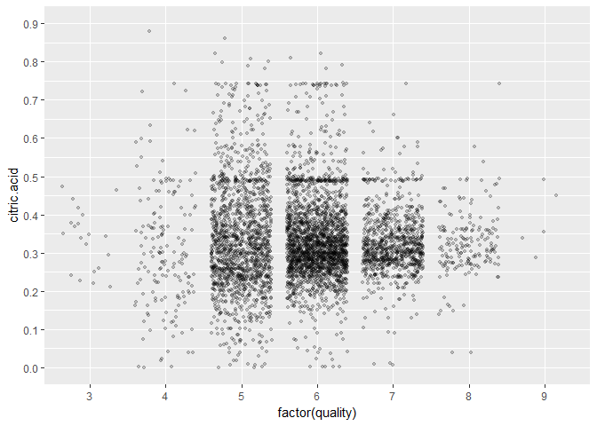

It seems that fixed acidity, volatile acidity, and citric acid level are not really correlated with quality.

### Quality and pH

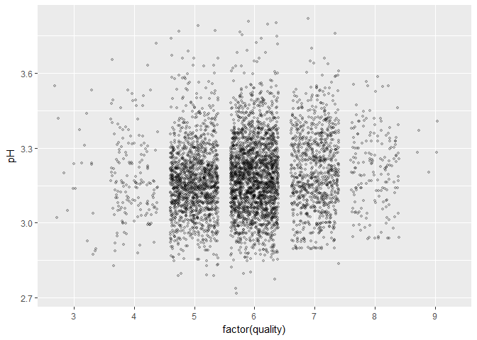

Again, there appears to be not much correlation between pH and quality.

### Free Sulfur Dioxide and Quality

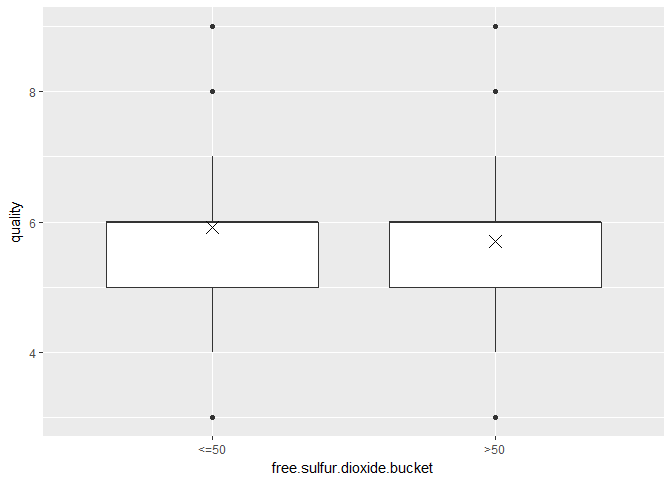

At first glance, the box plots seem unusual. It seems that there is no median and the quality ratings for wines in both groups have the same first and third quartile. So, I check the summary of quality ratings in both groups.

Summary of quality ratings of wine with more than 50 mg/dm<sup>3</sup> free sulfur dioxide:

```
##    Min. 1st Qu.  Median    Mean 3rd Qu.    Max.
##   3.000   5.000   6.000   5.705   6.000   9.000
```

Summary of quality ratings of wine with less than or equal to 50 mg/dm<sup>3</sup> free sulfur dioxide:

```
##    Min. 1st Qu.  Median    Mean 3rd Qu.    Max.
##   3.000   5.000   6.000   5.915   6.000   9.000
```

It appears that both groups have the same five number summary (minimum, first quartile, median, third quartile, maximum) in terms of quality ratings. The median and third quartile also have the same values in both groups. As a result, the lines that represent median and third quartile overlap each other and thus the median line cannot be seen.

### Residual Sugar and Alcohol

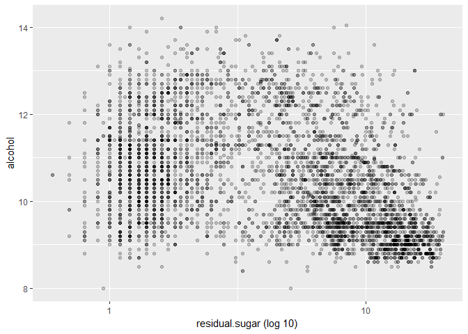

Pearson correlation coefficient (when log transformed):

```
## [1] -0.3934608
```

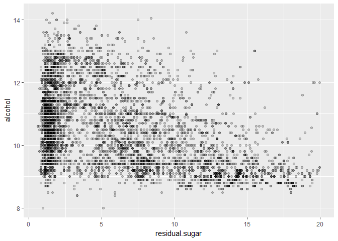

Pearson correlation coefficient (when not log transformed):

```
## [1] -0.4506312
```

It seems that there is some negative correlation between residual sugar and alcohol. Wines with higher residual sugar levels tend to have lower alcohol levels. The correlation is stronger when residual sugar data is not log transformed.

# Bivariate Analysis

### Talk about some of the relationships you observed in this part of the investigation. How did the feature(s) of interest vary with other features in the dataset?

Among the variables investigated, only alcohol level seem to be somewhat correlated to quality. There is a moderate positive correlation between alcohol level and quality. Other than that, residual sugar, fixed acidity, volatile acidity, citric acid, pH, and free sulfur dioxide do not seem to be correlated to quality.

### Did you observe any interesting relationships between the other features (not the main feature(s) of interest)?

There is a moderate negative correlation between residual sugar level and alcohol level. Wines with higher residual sugar levels tend to have lower alcohol levels.

### What was the strongest relationship you found?

Alcohol level has the strongest correlation with quality. However, they are only moderately correlated.

# Multivariate Plots Section

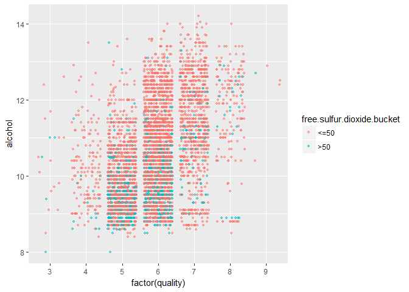

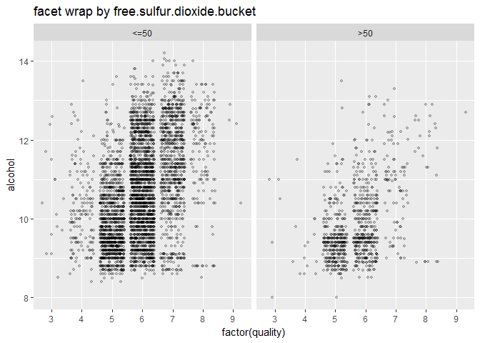

It seems that the trend is similar in both groups. Wines with higher alcohol levels tend to have higher quality ratings.

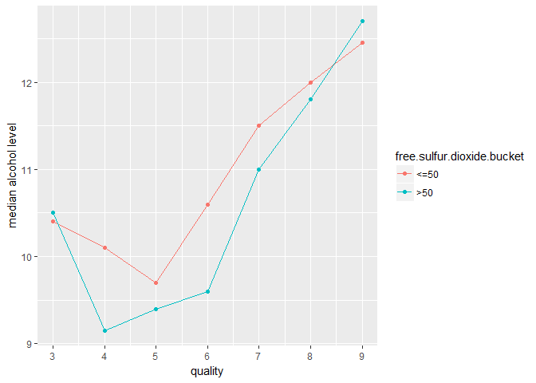

At the same quality rating, wines with greater than 50 mg/dm<sup>3</sup> free sulfur dioxide tend to have lower alcohol levels. However, in both groups, wines with higher quality ratings still tend to have higher alcohol levels.

# Multivariate Analysis

### Talk about some of the relationships you observed in this part of the investigation. Were there features that strengthened each other in terms of looking at your feature(s) of interest?

Regardless of whether free sulfur dioxide is greater than 50 mg/dm<sup>3</sup> or not, wines with higher quality ratings still tend to have higher alcohol levels.

### Were there any interesting or surprising interactions between features?

Surprisingly, there is no strong correlation between quality ratings and any variable.

# Final Plots and Summary

### Plot One

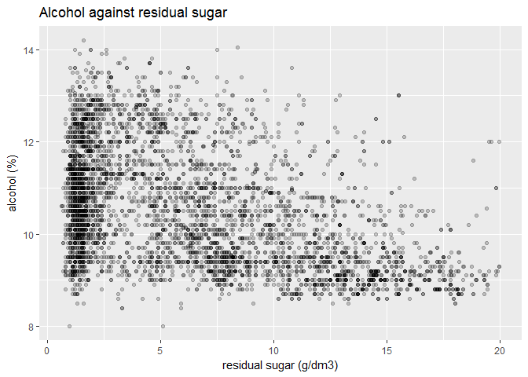

### Description One

Residual sugar level seems to be negatively correlated with alcohol level, but the correlation is only moderate. Wines with higher residual sugar levels tend to have lower alcohol levels.

### Plot Two

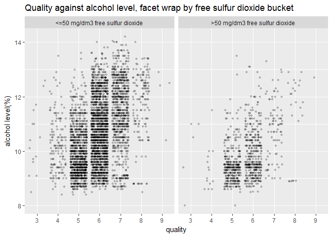

### Description Two

Wines with higher alcohol levels tend to have higher quality ratings. This suggests that there is some correlation between alcohol level and quality. This is the same for wines with free sulfur dioxide level greater than 50 mg/dm<sup>3</sup> and those not greater than 50 mg/dm<sup>3</sup>.

### Plot Three

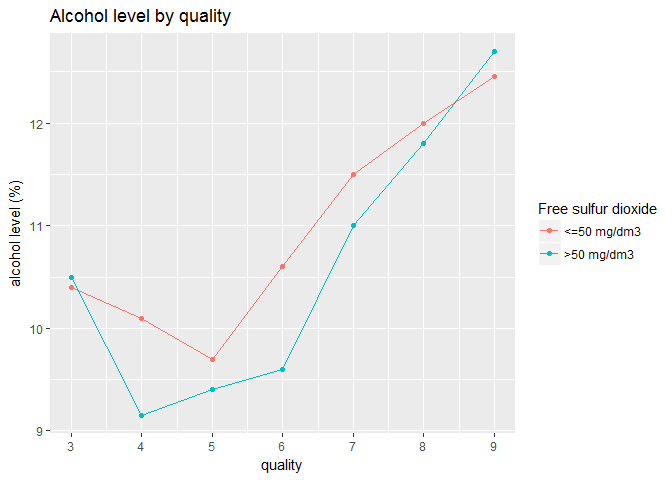

### Description Three

At the same quality rating, wines with greater than 50 mg/dm<sup>3</sup> free sulfur dioxide tend to have lower alcohol levels. However, in both groups, wines with higher quality ratings still tend to have higher alcohol levels. This further supports the correlation between alcohol levels and quality ratings.

# Reflection

The white wine dataset contains information of 4898 Portuguese “Vinho Verde” white wines, along with 11 variables about their chemical properties and 1 variable about their quality ratings. After understanding the variables of the dataset, I explored whether any variables are correlated to the wines’ quality ratings.

A major challenge in this exploratory data analysis is finding meaningful relationships between quality and other variables. It seems that no variable is strongly linked to wine quality, even though online resources claimed that some of them contribute to the smell and taste of wines. Only alcohol level is moderately correlated to quality.

One limitation of this dataset lies in the quality ratings. The minimum number of wine experts that evaluated the quality of each wine was 3, which I think is quite low. More experts should be involved in order to obtain a more objective quality rating. Also, through online research, I found that tannin also affects wine taste, but its concentration is not included in this dataset. In the future, tannin concentrations in wines should be measured so that their relationship with wine quality ratings could be explored.

# Dataset Source

P. Cortez, A. Cerdeira, F. Almeida, T. Matos and J. Reis. Modeling wine preferences by data mining from physicochemical properties. In Decision Support Systems, Elsevier, 47(4):547-553. ISSN: 0167-9236.

Available at: http://dx.doi.org/10.1016/j.dss.2009.05.016

# Reference

Renaming legend titles and labels:

- http://www.cookbook-r.com/Graphs/Legends_(ggplot2)/

Renaming facet labels:

- http://www.cookbook-r.com/Graphs/Facets_(ggplot2)/#modifying-facet-label-text

Factors that affect the smell or taste of wines:

- https://www.sciencehistory.org/distillations/magazine/scientia-vitis-decanting-the-chemistry-of-wine-flavor
- https://vinepair.com/articles/chemical-compounds-wine-taste-smell/